# Preprocessing of experiment da

## 3.4 Response times

We pre-registered to exclude participants with average response times less than 500ms.

First, let’s check the RT variable …

```r
E1 |>
  count(key_resp_2.rt) |>
  sample_n(20)   # 20 random rows
```

```
## # A tibble: 20 × 2
##    key_resp_2.rt     n
##    <chr>         <int>
##  1 4.1887            1
##  2 2.1452            1
##  3 1.4847            1
##  4 1.691             2
##  5 1.9139            1
##  6 1.642             1
##  7 3.4755            1
##  8 2.0105            1
##  9 1.2256            1
## 10 2.3706            1
## 11 2.26              2
## 12 1.6849            1
## 13 1.4085            1
## 14 1.1002            2
## 15 2.6635            1
## 16 2.6037            1
## 17 0.2489            1
## 18 2.9344            2
## 19 0.2468            1
## 20 3.6504            1
```

… and make it numeric (renamed into `rt`):

```r
E1 <- E1 |> mutate(rt = as.numeric(key_resp_2.rt)) |> select(-key_resp_2.rt)
```

Compute the by-participant averages and show distribution:

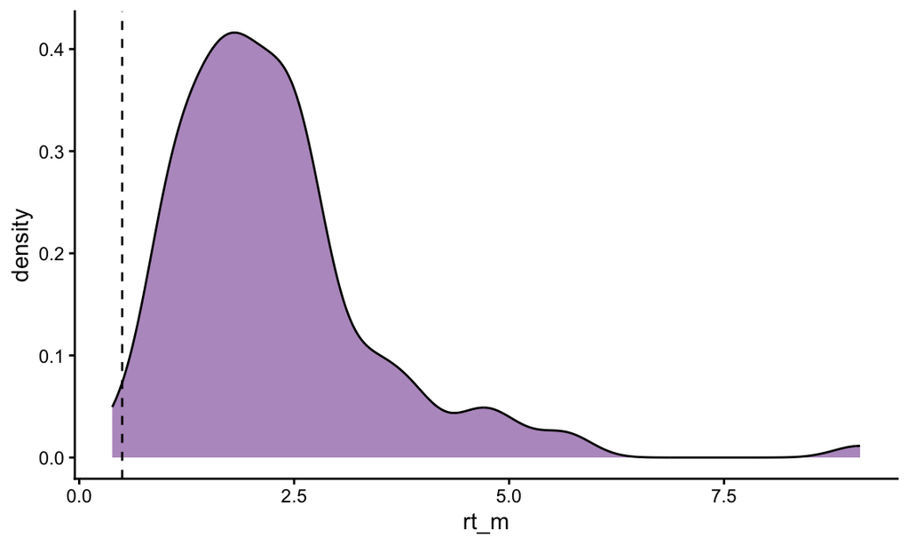

```r
E1_RT_avgs <- E1 |>
  group_by(participant) |>
  summarize(rt_m = mean(rt))

# Show distribution:

E1_RT_avgs |>
  ggplot(aes(x = rt_m)) +
  geom_density(fill = default_col, alpha = 0.5) +
  geom_vline(xintercept = 0.5, linetype = 'dashed') + # 500ms threshold
  theme_classic()
```

Find the corresponding participant IDs:

```r
fast_ppts <- E1_RT_avgs |>
  filter(rt_m <= 0.5) |>
  pull(participant)

# Check who they are:

fast_ppts
```

```
## [1] "123" "40"
```

Two participants are that fast: `123` and `40`.

Exclude them, check % and update totals:

```r
E1 <- filter(E1, !participant %in% fast_ppts)

# Check:

(1 - nrow(E1) / E1_total) * 100
```

```
## [1] 4.507042
```

```r
(1 - nrow(E1) / E1_running_total) * 100
```

```
## [1] 1.916817
```

```r
# Update running total:

E1_running_total <- nrow(E1)
```

**Note**: Check percentages.

## 3.5 Select relevant columns

Rename relevant columns into simpler variables and reduce tibble to just those columns:

```r
E1 <- E1 |>
  rename(word = Word, word_class = WordClass,
         acc = key_resp_2.corr) |>
  select(participant, word, word_class, rt, acc)
```

## 3.6 Merge item properties

Merge the item properties into the E1 tibble, reorder and rename columns:

```r
E1 <- E1 |>
  left_join(items, by = c('word' = 'romaji')) |>
  select(participant:word_class, rating:quantile, rt:acc) |>
  rename(icon = rating)
```

## 3.7 Create z-scored variables

Create z-scored variables:

```r
E1 <- E1 |>
  mutate(icon_z = icon - mean(icon),
         icon_z = icon_z / sd(icon_z),
         rt_z = rt - mean(rt),
         rt_z = rt_z / sd(rt_z)) |>
  relocate(icon_z, .after = icon) |>
  relocate(rt_z, .after = icon)
```

## 3.8 Save outside R

Show and save:

```r
E1
```

```
## # A tibble: 5,424 × 9
##    participant word      word_class  icon    rt_z  icon_z quantile    rt acc
##    <chr>       <chr>     <chr>      <dbl>   <dbl>   <dbl>    <dbl> <dbl> <chr>
##  1 100         fukameru  Verb       1      0.173  -1.06          1  2.62 0
##  2 100         tsuyoi    Adj        2.31  -0.0898  0.537         4  2.14 0
##  3 100         majimena  Adj        1.26  -0.117  -0.746         2  2.09 1
##  4 100         kuchi     Noun       2.2   -0.461   0.400         4  1.45 0
##  5 100         kasaneru  Verb       3.3   -0.0767  1.74          5  2.16 0
##  6 100         matomeru  Verb       2.36   0.743   0.599         4  3.67 1
##  7 100         mijikana  Adj        0.833  1.45   -1.27          1  4.97 0
##  8 100         mizu      Noun       1.5    1.02   -0.454         2  4.17 1
##  9 100         mitsumeru Verb       1.92   0.461   0.0619        3  3.15 1
## 10 100         kebakeba  Mim        2      1.81    0.156         3  5.63 1
## # ℹ 5,414 more rows
```

```r
write_csv(E1, '../data/E1_processed.csv')
```

# 4 Data wrangling: Experiment 2

## 4.1 Create accuracy variable

For E2, we need to manually create an accuracy variable:

```r
E2 <- E2 |>
  mutate(acc = case_when(key_resp_3.keys == CorrectKey ~ '1',
                         key_resp_3.keys != CorrectKey ~ '0'))

# Check:

select(E2, key_resp_3.keys, CorrectKey, acc)
```

```
## # A tibble: 6,000 × 3
##    key_resp_3.keys CorrectKey acc
##    <chr>           <chr>      <chr>
##  1 s               s          1
##  2 s               s          1
##  3 k               k          1
##  4 s               s          1
##  5 k               s          0
##  6 k               k          1
##  7 s               s          1
##  8 s               k          0
##  9 k               k          1
## 10 s               k          0
## # ℹ 5,990 more rows
```

Looks good.

## 4.2 Attention checks

Anybody who failed attention checks?

```r
E2_fails <- E2 |>
  filter(WordClass == 'AttentionCheck' & acc == 0) |>
  pull(participant)

# Show:

E2_fails
```

```
## [1] "135"
```

```r
length(E2_fails) / E2_ppts * 100
```

```
## [1] 0.8264463
```

```r
nrow(filter(E2, participant %in% E2_fails, WordClass != 'AttentionCheck')) / E2_total * 100
```

```
## [1] 0.8333333
```

Exclude these participants (ids stored in `E2_fails` vector from last chunk):

```r
E2 <- E2 |>
  filter(!participant %in% E2_fails)
```

Now we can get rid of the attention check rows in the main data:

```r
E2 <- E2 |> filter(WordClass != 'AttentionCheck')

# Update running total:

E2_running_total <- nrow(E2)
```

## 4.3 Incomplete

## 4.4 Not completed

Check how many trials each participant completed and whether there’s some who didn’t complete the experiment:

```r
E2 |>
  count(participant) |>
  count(n)
```

```
## Storing counts in `nn`, as `n` already present in input
## ℹ Use `name = "new_name"` to pick a new name.
```

```
## # A tibble: 1 × 2
##       n    nn
##   <int> <int>
## 1    48   119
```

They all completed it all - no need to exclude anyone based on this criterion.

## 4.5 Same key

We pre-registered to exclude participants who would press the same key >80% of the time.

Let’s look at the distribution of % key responses.

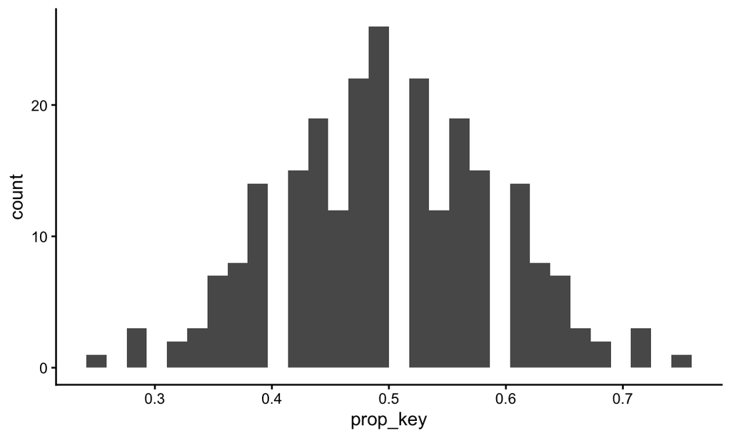

```r
E2 |>
  count(participant, key_resp_3.keys) |>
  mutate(prop_key = n / 48) |>
  ggplot(aes(x = prop_key)) +
  geom_histogram() +
  theme_classic()
```

```r
E2 |>
  count(participant, key_resp_3.keys) |>
  mutate(prop_key = n / 48) |>
  filter(prop_key > 0.8 | prop_key < 0.2)
```

```
## # A tibble: 0 × 4
## # ℹ 4 variables: participant <chr>, key_resp_3.keys <chr>, n <int>,
## #   prop_key <dbl>
```

Actually no, so we’re good here.

## 4.6 Response times

Same as for E1, pre-registered <500ms (participant average) exclusion criterion:

First, let’s check the RT variable …

```r
E2 |>
  count(key_resp_3.rt) |>
  sample_n(20)   # 20 random rows
```

```
## # A tibble: 20 × 2
##    key_resp_3.rt     n
##    <chr>         <int>
##  1 2.117             1
##  2 5.6111            1
##  3 1.711             2
##  4 1.296             1
##  5 3.2872            1
##  6 3.0025            1
##  7 2.4973            1
##  8 1.689             1
##  9 1.3093            1
## 10 0.0821            1
## 11 3.045             1
## 12 1.9463            1
## 13 0.5849            1
## 14 1.4156            1
## 15 1.2713            1
## 16 8.8994            1
## 17 1.7347            1
## 18 1.0885            1
## 19 0.9802            2
## 20 1.191             1
```

… and make it numeric (renamed into `rt`):

```r
E2 <- E2 |> mutate(rt = as.numeric(key_resp_3.rt)) |> select(-key_resp_3.rt)
```

Compute the by-participant averages and show distribution:

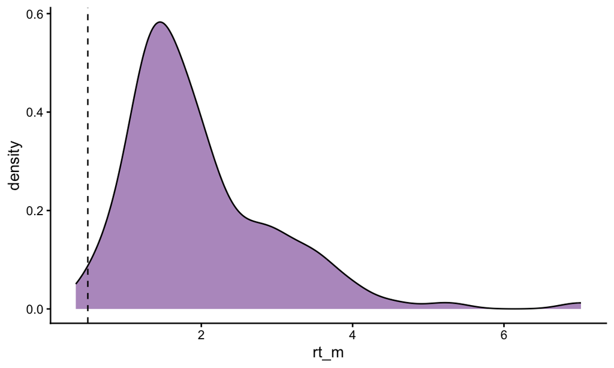

```r
E2_RT_avgs <- E2 |>
  group_by(participant) |>
  summarize(rt_m = mean(rt))

# Show distribution:

E2_RT_avgs |>
  ggplot(aes(x = rt_m)) +
  geom_density(fill = default_col, alpha = 0.5) +
  geom_vline(xintercept = 0.5, linetype = 'dashed') + # 500ms threshold
  theme_classic()
```

Find the corresponding participant IDs:

```r
fast_ppts <- E2_RT_avgs |>
  filter(rt_m <= 0.5) |>
  pull(participant)

# Check who they are:

fast_ppts
```

```
## [1] "66"
```

This time only one participant: `66`.

Exclude them, check % and update totals:

```r
E2 <- filter(E2, !participant %in% fast_ppts)

# Check:

(1 - nrow(E2) / E2_total) * 100
```

```
## [1] 1.666667
```

```r
(1 - nrow(E2) / E2_running_total) * 100
```

```
## [1] 0.8403361
```

```r
# Update running total:

E2_running_total <- nrow(E1)
```

**Note**: Check percentages.

## 4.7 Select relevant columns

Rename relevant columns into simpler variables and reduce tibble to just those columns:

```r
E2 <- E2 |>
  rename(word = Word, word_class = WordClass) |>
  select(participant, word, word_class, rt, acc)
```

## 4.8 Merge item properties

```r
E2 <- E2 |>
  left_join(items, by = c('word' = 'romaji')) |>
  select(participant:word_class, rating:quantile, rt:acc) |>
  rename(icon = rating)
```

## 4.9 Create z-scored variables

Create z-scored variables:

```r
E2 <- E2 |>
  mutate(icon_z = icon - mean(icon),
         icon_z = icon_z / sd(icon_z),
         rt_z = rt - mean(rt),
         rt_z = rt_z / sd(rt_z)) |>
  relocate(icon_z, .after = icon) |>
  relocate(rt_z, .after = icon)
```

## 4.10 Save outside R

Show and save:

```r
E2
```

```
## # A tibble: 5,664 × 9
##    participant word     word_class  icon    rt_z  icon_z quantile    rt acc
##    <chr>       <chr>    <chr>      <dbl>   <dbl>   <dbl>    <dbl> <dbl> <chr>
##  1 101         tsuma    Noun       0.65   0.454  -1.50          1 3.10  1
##  2 101         hiratai  Adj        2.91   0.0507  1.28          5 2.12  1
##  3 101         kasanaru Verb       1.86  -0.321  -0.0134        3 1.22  1
##  4 101         kotoba   Noun       2.73  -0.529   1.06          5 0.709 0
##  5 101         hoka     Noun       3     -0.231   1.39          5 1.43  1
##  6 101         yomu     Verb       2.12   0.174   0.316         4 2.42  0
##  7 101         tochi    Noun       1.2   -0.259  -0.821         2 1.37  1
##  8 101         nemui    Adj        3.58  -0.624   2.11          5 0.477 0
##  9 101         yobu     Verb       0.417 -0.161  -1.78          1 1.60  0
## 10 101         majimena Adj        1.26   0.0149 -0.746         2 2.03  1
## # ℹ 5,654 more rows
```

```r
write_csv(E2, '../data/E2_processed.csv')
```